# Movie Recommendation Engine (group 10)

Qianyun Zhang, Yi Liu, Danmo Wang, Zehao Wang, Zhibo Wan

April,13,2016

## Introduction

In this project, we attempt to use the user-based Collaborative Filtering approach to build a basic movie recommendation engine and analyze the information of the movies.There are 4 parts of the this presentation:

- The Dataset
- The user-based Collaborative Filtering approach
- Movie Recommendation Engine
- Shiny App: Movie Analysis

[figure not shown]

## The Dataset

We firstly use the dataset “movie.csv”.In order to keep the recommender simple, we select the 5000 movies with most reviews based on ASIN and then compare the result with OMDB data, filtering out ASIN point to the same movies.

## Data Processing

```r
knitr::opts_chunk$set(echo = TRUE)

library(dplyr)
library(tidyr)
library(hexbin)

##Parsing the helpfuness votes

movies.raw=read.csv("~/Desktop/project4/moviescsv.csv")

movies.raw=movies.raw%>%
  separate(review_helpfulness,
           c("helpful.v", "total.v"), sep = "/",
           remove=FALSE)
movies.raw=movies.raw%>%mutate(review_h=as.numeric(helpful.v)/as.numeric(total.v))
sample_n(movies.raw, 3)
```

```
##         product_productid  review_userid review_helpfulness helpful.v
## 2415603        B0002KVUKW A2S14TSRH6CMKP                1/3         1
## 1460575      6302403596.0 A2V29IO9JQQF5P                0/1         0
## 1350799        B00008AOVN A2WQJB9PQ8PCET                0/0         0
##         total.v review_score  review_h
## 2415603       3            3 0.3333333
## 1460575       1            3 0.0000000
## 1350799       0            4       NaN
```

```r
##Compute some user summaries
user.table=movies.raw%>%
  #sample_n(100000)%>%
  group_by(review_userid)%>%
  summarize(
    user.count=n(),
    UReview_ave=mean(review_score, na.rm=T),
    UReview_read=mean(as.numeric(total.v), na.rm=T),
    UReview_help=mean(review_h, na.rm=T)
  )
head(user.table, n=3)
```

```
## Source: local data frame [3 x 5]
##
##        review_userid user.count UReview_ave UReview_read UReview_help
##               (fctr)      (int)       (dbl)        (dbl)        (dbl)
## 1                            12        4.25     2.833333    0.8785714
## 2 #oc-R1FQ7AEZE601ZD          1        1.00     8.000000    0.3750000
## 3 #oc-R2ZIMCXX9A2H0D          1        1.00    44.000000    0.2727273
```

```r
##compute some movie summaries
product.table=movies.raw%>%
  #sample_n(100000)%>%
  group_by(product_productid)%>%
  summarize(
    prod.count=n(),
    PReview_read=sum(as.numeric(total.v)),
    PReview_ave=mean(review_score, na.rm=F)
  )

head(product.table, n=3)
```

```
## Source: local data frame [3 x 4]
##
##   product_productid prod.count PReview_read PReview_ave
##              (fctr)      (int)        (dbl)       (dbl)
## 1                           12           34        4.25
## 2        000500005X          3           43        5.00
## 3        000500411X          1            2        5.00
```

```r
product.table_sort=product.table[with(product.table,order(-product.table$prod.count)),]

product_5000=head(product.table_sort,n=5000)
```

## OMDB

```r
library(rvest)
library(tidyr)
library(devtools)
# Install omdbapi
devtools::install_github("hrbrmstr/omdbapi")

library(omdbapi)
library(pbapply)
library(dplyr)
library(stringr)
# Example 1, not found in OMDB
# ASIN.inq="000500005X"
# Example 2, found in OMDB
ASIN.list=product_5000$product_productid

#######below is data clean part###################################################################
ASIN.str=toString(ASIN.list)
ASIN.str.left=ASIN.str

pivot=1
ASIN.GoodList=c()

while(toString(pivot)!="NA")
{
  pos=str_locate(ASIN.str.left,",")
  pivot=pos[1]
  ASIN.tmp=substr(ASIN.str.left,1,pivot-1)


    if(toString(as.numeric(ASIN.tmp))!="NA")
    {
      ASIN.tmp=substr(ASIN.tmp,1,str_length(ASIN.tmp)-2)
    }

  ASIN.GoodList=c(ASIN.GoodList,ASIN.tmp)
  ASIN.str.left=substring(ASIN.str.left,pivot+2)

}

ASIN.GoodList=ASIN.GoodList[1:499]

####below is feature


features_name=c("Rated","Type")

feature_table=NULL


for(i in 1:length(ASIN.GoodList))
{
movie1=NULL
movie1.title=NULL

ASIN.inq=ASIN.GoodList[i] # this movie's title has a "("

movie1<-tryCatch( {html(paste("http://www.amazon.com/exec/obidos/ASIN/", ASIN.inq, sep=""))},error=function(e){})


if(is.null(movie1)){next}

movie1.title=
  movie1 %>%
  html_node("title") %>%
  html_text()

movie1.title=strsplit(movie1.title, ": ")[[1]][2]
movie1.title=strsplit(movie1.title, " \\[")[[1]][1]
movie1.title=strsplit(movie1.title, " \\(")[[1]][1]

movie1.title=substr(movie1.title,1,45)



tryCatch({omdb.entry=search_by_title(movie1.title)},error=function(e){})

if(length(omdb.entry)==0){next}


movie_feature=find_by_id(omdb.entry$imdbID[1], include_tomatoes=T)

tmp_row=c(ASIN.inq,movie1.title)
feature_list=names(movie_feature)

for(j in 1:length(features_name))
{
  index=match(features_name[j],feature_list)
  tmp_row=c(tmp_row,movie_feature[index])

}
feature_table=rbind(feature_table,tmp_row)
}
```

## Algorithms we have tried

We have tryed the Movie Recommendation System of “Beer Dataset”, but unfortunately it doesn’t fit well to the movie dataset. It puts the information of user-based onto the item-based.To illustrate it, For movie 1,if all the ratings of users are 10,and for movie 2, all the ratings are 1,their correlation is 1,which is not true.

## Slope One(item-based algorithm)

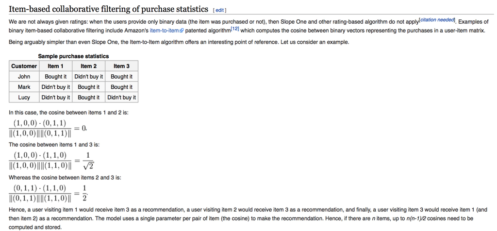

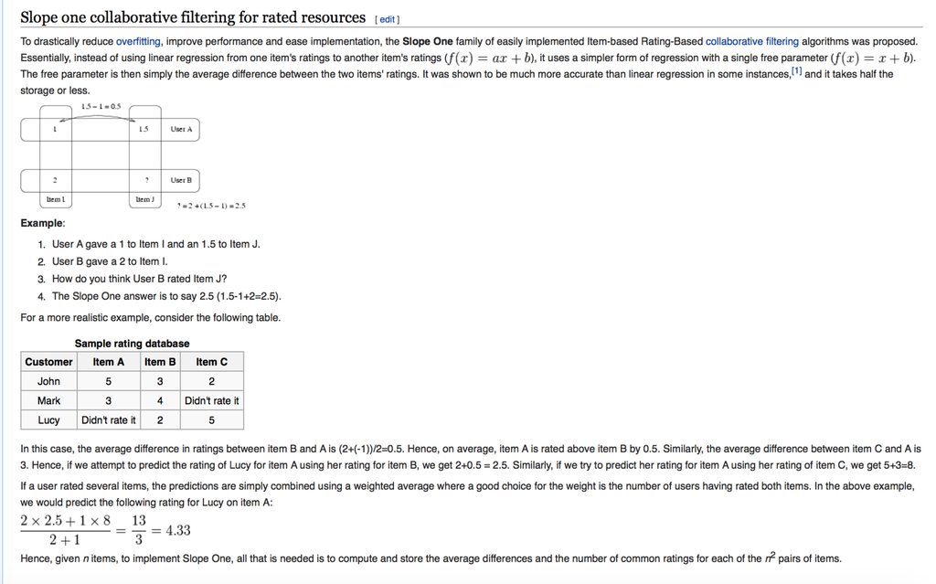

Since there are too many Users,and it’s really complicted to add all the missing-values of the ratings.

## The user-based Collaborative Filtering approach

The User-Based Collaborative Filtering approach groups users according to their preferences, and then recommends an item that a similar user in the same group viewed or liked.  
For example, if user 1 liked movie A, B and C, and if user 2 liked movie A and B, then movie C might make a good recommendation to user 2.  
Hence in this post, We will use User-Based Collaborative Filtering based on “Cosine Similarity” Algorithm to generate a top-5 recommendation list for users Then given your UserID, we identify the most similar users and then return the movies that are similar to the movies already liked by the user.

## Cosine Similarity

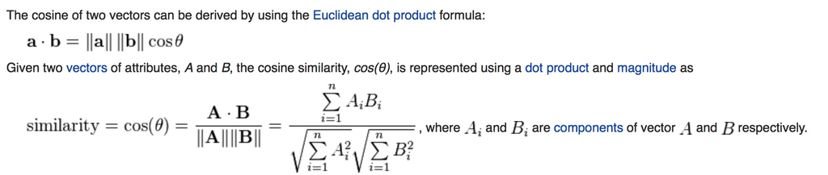

In this case, A and B represents the vector of all the movie ratings from two Users.  
For example

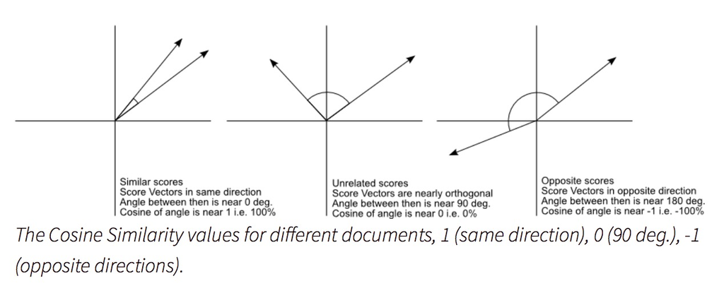

We reshape the data and construct a big matrix where the columns are the product IDs and the rows are the User IDs

```r
library("plyr")
library("reshape2")
setwd("E:/W4249")
data<-read.csv("moviescsv.csv")
matrix<-acast(data[1:200,],review_userid~product_productid,value.var="review_score")
matrix[is.na(matrix)]<-0
similarity <- function(u1, u2){
  c1<-matrix[which(rownames(matrix)==u1),]
  c2<-matrix[which(rownames(matrix)==u2),]
  corr<-crossprod(c1,c2)/(norm(as.matrix(c1),"f")*norm(as.matrix(c2),"f"))
  corr
}
user.pairs <- expand.grid(user1=rownames(matrix), user2=rownames(matrix))
user.pairs <- subset(user.pairs, user1!=user2)
results <- ddply(user.pairs, .(user1, user2), function(x) {
  #b1 <- beer_name_to_id(x$beer1)
  #b2 <- beer_name_to_id(x$beer2)
  c("sim"=similarity(x$user1, x$user2))
}, .progress="text")

recursivefunction<-function(myid,b,n=5,j=1){
  c1<-matrix[which(rownames(matrix)==myid),]
  c2<-matrix[which(rownames(matrix)==b[1]),]
  for(i in 1:length(c1)){
    if (c1[i]==0 & c2[i]>1){
      if(!(names(c1)[i] %in% movie)){
        movie[j]=names(c1)[i]
        j=j+1
      }
    }
  }
  if(j<n+1){
    if(length(b)==0){
      return(movie)
    }
    else{
      b<-b[-1]
      recursivefunction(myid,b,n=5,j)
    }
  }
  else{
    return(movie)
  }
}

find_similarity_movie<-function(myid,n=5){
  similar <- subset(results, user1==myid)
  similar <- similar[order(-similar$sim),]
  b<-similar[,2]
  movie<-rep(NA,n)
  recursivefunction(myid,b,n=5,j=1)
}
```

## Movie Recommendation Engine

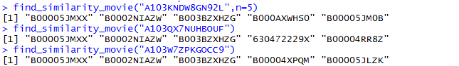

## Movie Analysis

We analyzed the relationship between director names, Genre, Production industry and PReview_average scores, counts.

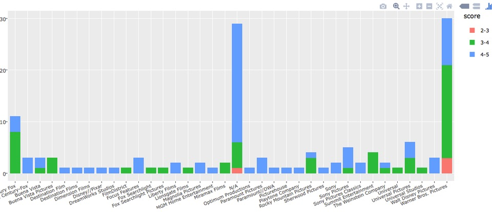

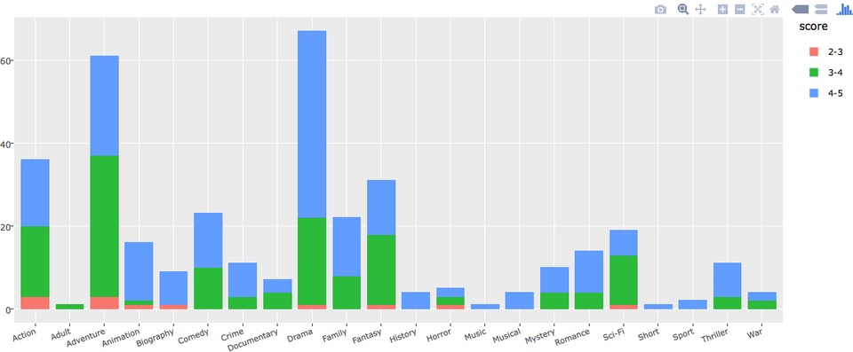

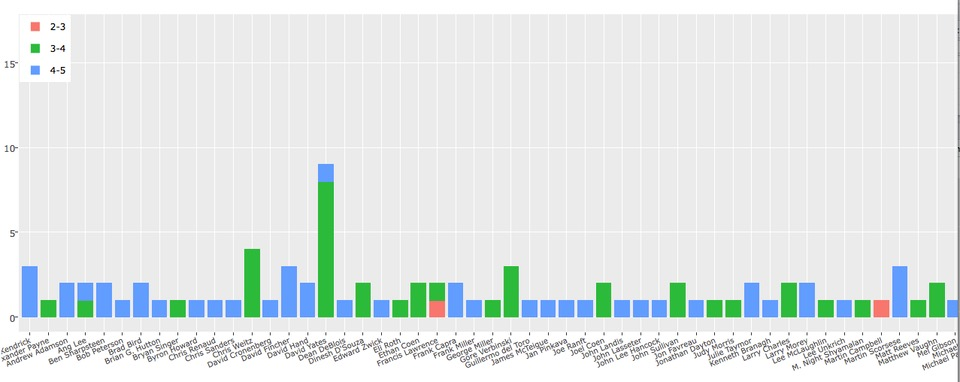

Then we select Geere, Year, PReview_average, Awards, Production Industry of the data and make a shiny app. We don’t choose reviews because we have selected the 5000 movies with most reviews so it may not be distinct.

For example

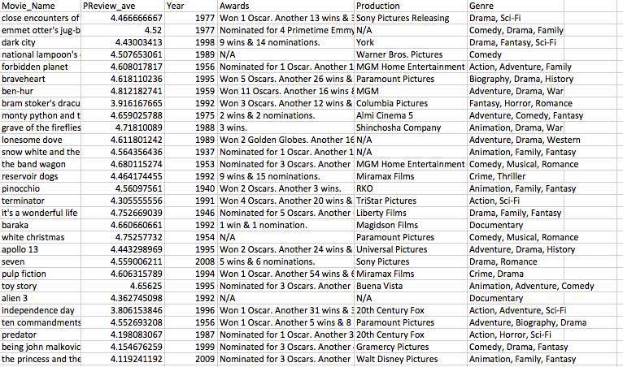

Here are the codes of Shiny UI ande Server  
Shiny UI

```r
library(shiny)
library(plotly)
library(dplyr)
library(splitstackshape)
library(ggplot2)
library(shinydashboard)
# Define UI for application that draws a histogram
shinyUI(fluidPage(titlePanel("Movie Movie Movie"),

                            # Sidebar with a selector input for neighborhood
                            sidebarLayout(position="left",
                                          sidebarPanel(
                                            conditionalPanel(condition="input.Panels==1",
                                                             helpText("Give the overall analysis"),
                                                             br(),
                                                             selectInput("Plot", "Analysis",
                                                                         c("Year", "Awards"))
                                            ),
                                            conditionalPanel(condition="input.Panels==2",
                                                             helpText("Choose the genre"),
                                                             hr(),
                                                             selectInput("genre", "Genre (a movie can have multiple genres)",
                                                                         c( "Action", "Adventure", "Animation", "Biography", "Comedy",
                                                                            "Crime", "Documentary", "Drama", "Family", "Fantasy", "History",
                                                                            "Horror", "Music", "Musical", "Mystery", "Romance", "Sci-Fi",
                                                                            "Short", "Sport", "Thriller", "War", "Western"))

                                            ),
                                            conditionalPanel(condition="input.Panels==3",
                                                             helpText("Choose the genre"),
                                                             hr()
                                            )
                                          ),
                                          mainPanel(
                                            tabsetPanel(type="pill",

                                                        tabPanel("Analysis", br(),plotlyOutput("distplot1") , value=1),

                                                        tabPanel("Genre Analysis", br(), plotlyOutput("distplot2"), value=2),
                                                        tabPanel("engine", br(), helpText("Choose the genre"), value=3),

                                                        id = "Panels"
                                            )
                                          )



                   )
))
```

Shiny Server

```r
library(shiny)

# Define server logic required to draw a histogram
shinyServer(function(input, output) {
  genre <- read.csv("genre.csv")
  test <- read.csv("test.csv")
  output$distplot1 <- renderPlotly(
    if (input$Plot >0){
      if (input$Plot =="Year"){
        year <- test %>%
          group_by(Year) %>%
          summarize(
            count = n())
        plot_ly(year, x = Year, y = count) %>% layout(title = "number of movies")
      }
      else if (input$Plot == "Awards"){
        plot_ly(data = test, x = Year, y = PReview_ave, color = awards, text=paste("Title:", test$Movie_Name), mode = "markers")
      }

    })

    output$distplot2 <- renderPlotly(
      if(input$genre >0){
        genre$Genre <- as.character(genre$Genre)
        drama <- genre[which(genre$Genre == as.character(input$genre)),]
        plot_ly(drama, x = Year, y =PReview_ave,color = awards,text=paste("Title:", drama$Movie_Name), mode = "markers" ,colors=c("#f03b20","#7fcdbb"))

      }

    )

})
```